# Ankara Genelinde Seçim Sonuçları

secimler R paketi otomatik raporlama

2017-02-23

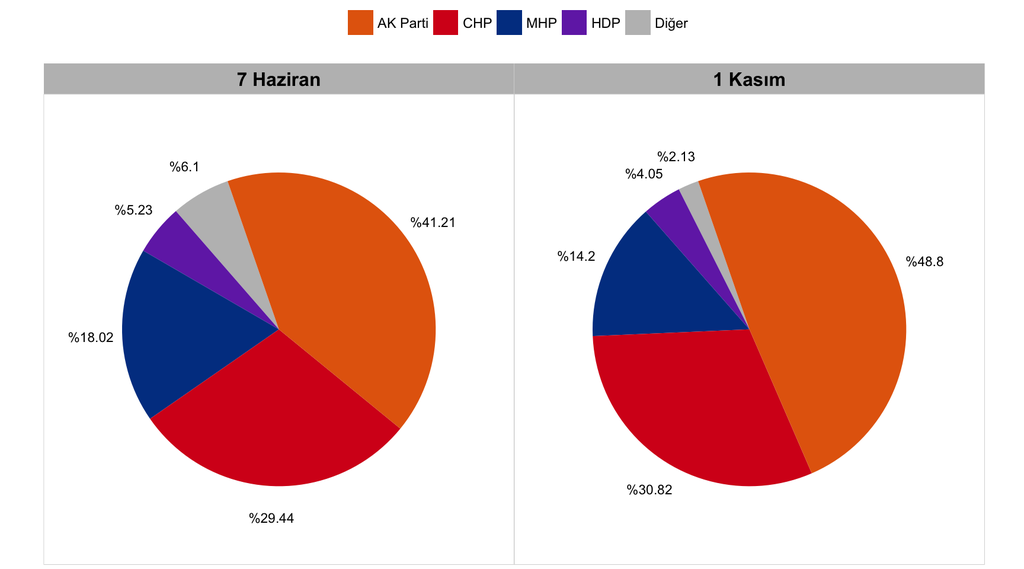

7 Haziran ve 1 Kasım 2015 genel seçimlerinin oy oranı bazında karşılaştırması.

# 7 Haziran 2015 Genel Seçimi Özet Bilgiler

Ankara ilinde bu seçimde 2 seçim bölgesi 25 ilçe, 1430 mahalle, 9 cezaevi ve toplamda 10.791 seçim sandığı bulunmaktadır. İl içerisinde toplam 3.703.253 kayıtlı seçmen bulunmaktadır. 3.265.996 seçmen oy kullanmış, geçerli oy sayısı ise 3.204.511 olmuştur. Seçime katılım oranı %88,19 olarak gerçekleşmiştir.

Toplam sonuçlarda AK Parti %41,21, CHP %29,44, MHP %18,02, HDP %5,23 ve diğer partiler ile bağımsızlar %6,1 oy oranına sahip olmuşlardır. Ankara, 81 il arasından, partilerin kendi içindeki oy oranları sıralamalarına göre AK Parti’nin 44, CHP’nin 17, MHP’nin 45 ve HDP’nin 36. sıradaki ili olmuştur.[^1]

Ankara 1. bölge Akyurt, Bala, Çankaya, Elmadağ, Etimesgut, Evren, Gölbaşı, Haymana, Mamak, Polatlı, Şereflikoçhisar ve Sincan ilçelerini kapsamaktadır.Bu bölgede 12 ilçe, 694 mahalle, 4 cezaevi ve toplamda 5.936 seçim sandığı bulunmaktadır. Seçim bölgesi içerisinde toplam 2.074.389 kayıtlı seçmen bulunmaktadır. 1.829.743 seçmen oy kullanmış, geçerli oy sayısı ise 1.797.588 olmuştur. Seçime katılım oranı %88,21 olarak gerçekleşmiştir.

Toplam sonuçlarda AK Parti %36,33, CHP %33,55, MHP %18,26, HDP %6,21 ve diğer partiler ile bağımsızlar %5,65 oy oranına sahip olmuşlardır.

Ankara 2. bölge Altındağ, Ayaş, Beypazarı, Çamlıdere, Çubuk, Güdül, Kalecik, Kazan, Keçiören, Kızılcahamam, Nallıhan, Pursaklar ve Yenimahalle ilçelerini kapsamaktadır.Bu bölgede 13 ilçe, 736 mahalle, 5 cezaevi ve toplamda 4.855 seçim sandığı bulunmaktadır. Seçim bölgesi içerisinde toplam 1.628.864 kayıtlı seçmen bulunmaktadır. 1.436.253 seçmen oy kullanmış, geçerli oy sayısı ise 1.406.923 olmuştur. Seçime katılım oranı %88,18 olarak gerçekleşmiştir.

Toplam sonuçlarda AK Parti %47,44, CHP %24,2, MHP %17,71, HDP %3,98 ve diğer partiler ile bağımsızlar %6,67 oy oranına sahip olmuşlardır.

İl içerisinde sandık bazında partilere oy oranı dağılımı aşağıdaki grafikte gösterilmiştir. Kutu grafiğini yorumlamak için orta çizgi ortanca (medyan), alt ve üst çizgiler sırasıyla %25 ve %75lik dilimler ve noktalar da uç değerleri (outlier) göstermektedir. *(Örneğin bir partinin grafiğinin orta çizgisi %40 değerindeyse, sandıkların yarısında %40 ve üzeri, diğer yarısında ise %40 altı oy oranı var demektir.)*

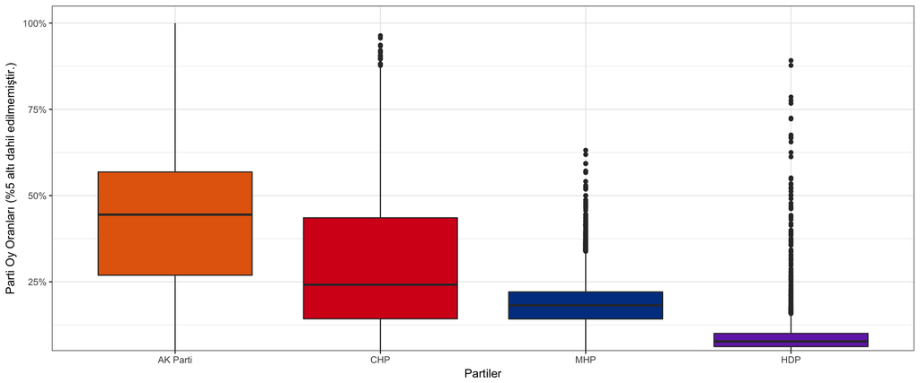

7 Haziran seçimlerinde partilerin seçim çevrelerinden aldıkları oy oranları kutu grafiği.

# 1 Kasım 2015 Genel Seçimi Özet Bilgiler

Ankara ilinde bu seçimde 2 seçim bölgesi 25 ilçe, 1430 mahalle, 8 cezaevi ve toplamda 10.888 seçim sandığı bulunmaktadır. İl içerisinde toplam 3.743.623 kayıtlı seçmen bulunmaktadır. 3.353.719 seçmen oy kullanmış, geçerli oy sayısı ise 3.317.826 olmuştur. Seçime katılım oranı %89,58 olarak gerçekleşmiştir.

Toplam sonuçlarda AK Parti %48,8, CHP %30,82, MHP %14,2, HDP %4,05 ve diğer partiler ile bağımsızlar %2,13 oy oranına sahip olmuşlardır. Ankara, 81 il arasından, partilerin kendi içindeki oy oranları sıralamalarına göre AK Parti’nin 47, CHP’nin 17, MHP’nin 33 ve HDP’nin 35. sıradaki ili olmuştur.[^2]

Ankara 1. bölge Akyurt, Bala, Çankaya, Elmadağ, Etimesgut, Evren, Gölbaşı, Haymana, Mamak, Polatlı, Şereflikoçhisar ve Sincan ilçelerini kapsamaktadır.Bu bölgede 12 ilçe, 694 mahalle, 3 cezaevi ve toplamda 5.980 seçim sandığı bulunmaktadır. Seçim bölgesi içerisinde toplam 2.097.017 kayıtlı seçmen bulunmaktadır. 1.877.319 seçmen oy kullanmış, geçerli oy sayısı ise 1.858.264 olmuştur. Seçime katılım oranı %89,52 olarak gerçekleşmiştir.

Toplam sonuçlarda AK Parti %43,52, CHP %35,22, MHP %14,31, HDP %4,87 ve diğer partiler ile bağımsızlar %2,09 oy oranına sahip olmuşlardır.

Ankara 2. bölge Altındağ, Ayaş, Beypazarı, Çamlıdere, Çubuk, Güdül, Kalecik, Kazan, Keçiören, Kızılcahamam, Nallıhan, Pursaklar ve Yenimahalle ilçelerini kapsamaktadır.Bu bölgede 13 ilçe, 736 mahalle, 5 cezaevi ve toplamda 4.908 seçim sandığı bulunmaktadır. Seçim bölgesi içerisinde toplam 1.646.606 kayıtlı seçmen bulunmaktadır. 1.476.400 seçmen oy kullanmış, geçerli oy sayısı ise 1.459.562 olmuştur. Seçime katılım oranı %89,66 olarak gerçekleşmiştir.

Toplam sonuçlarda AK Parti %55,51, CHP %25,22, MHP %14,06, HDP %3,01 ve diğer partiler ile bağımsızlar %2,2 oy oranına sahip olmuşlardır.

İl içerisinde sandık bazında partilere oy oranı dağılımı aşağıdaki grafikte gösterilmiştir. Kutu grafiğini yorumlamak için orta çizgi ortanca (medyan), alt ve üst çizgiler sırasıyla %25 ve %75lik dilimler ve noktalar da uç değerleri (outlier) göstermektedir. *(Örneğin bir partinin grafiğinin orta çizgisi %40 değerindeyse, sandıkların yarısında %40 ve üzeri, diğer yarısında ise %40 altı oy oranı var demektir.)*

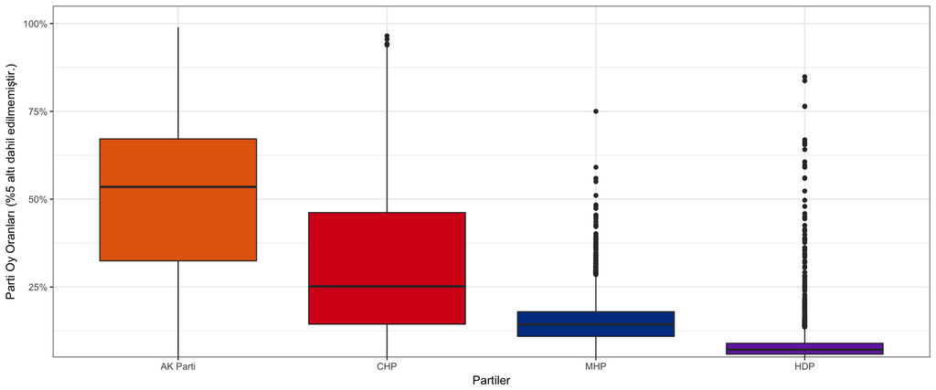

1 Kasım seçimlerinde partilerin seçim çevrelerinden aldıkları oy oranları kutu grafiği.

# Oy Kaymaları

7 Haziran ve 1 Kasım arasında partiler arasında oy kaymaları yaşanmıştır. Bu oy kaymaları seçim birimi bazındaki oy oranı değişimlerinin incelenmesi sonucu hesaplanmaktadır. Aşağıdaki tablolarda partiler arasındaki oy kaymaları verilmektedir. Tablolardaki oy kaymalarını incelerken lütfen aşağıdaki maddelere dikkat ediniz.

- Oy kaymaları satırdan sütuna okunmalıdır.
- Oy kaymaları puan bazındadır. Örneğin MHP’den AK Parti’ye %10 bir kayma; MHP’nin oylarının %10’unu değil, bütün oyların bir önceki seçimde MHP’ye ait olan %10luk kesimini belirtmektedir.
- Partilerin farklı sandıklarda oy oranları farklı şekillerde değiştiğinden iki partiden de birbirlerine oy kayması mümkün olabilir. Net oy kayması ayrı bir tabloda verilmiştir.
- Partiler arasında zincir olarak oy kayması yaşanmış olabilir. Örneğin MHP’den CHP’ye net oy kayması yaşanırken, CHP’den de AK Parti’ye net oy kayması yaşanmış olabilir.

Partiler arasındaki oy oranı kaymaları.

|  | AK Parti | CHP | MHP | HDP | Diğer |
| --- | --- | --- | --- | --- | --- |
| AK Parti | 0 | %0.01 | %0 | %0 | %0 |
| CHP | %0.27 | 0 | %0 | %0 | %0 |
| MHP | %3.17 | %0.65 | 0 | %0 | %0.01 |
| HDP | %0.85 | %0.29 | %0 | 0 | %0 |
| Diğer | %3.18 | %0.8 | %0.01 | %0 | 0 |

Partiler arasındaki net oy oranı kaymaları.

|  | AK Parti | CHP | MHP | HDP | Diğer |
| --- | --- | --- | --- | --- | --- |
| AK Parti | %0 | %0 | %0 | %0 | %0 |
| CHP | %0.26 | %0 | %0 | %0 | %0 |
| MHP | %3.17 | %0.65 | %0 | %0 | %0 |
| HDP | %0.85 | %0.29 | %0 | %0 | %0 |
| Diğer | %3.17 | %0.8 | %0 | %0 | %0 |

# İlçe Bazında Karşılaştırmalar

Aşağıdaki bilgilerde ilçe bazında özet grafikler bulunmaktadır. Bu grafiklerde her ilçenin toplam kayıtlı seçmen sayısı, geçerli oy sayısı, geçersiz oy sayısı ve barajı aşan partilerin (AK Parti, CHP, MHP ve HDP) oy oranları bulunmaktadır. İlçeler hakkında detaylı bilgi edinmek için ilçelerin kendi raporlarını inceleyebilirsiniz. *(Detaylı bilgi dökümanın sonunda yer almaktadır.)*

## Seçmen İstatistikleri

Kayıtlı seçmen sayısındaki değişim en yüksek oranda Etimesgut (+%3.16) ilçesinde ve en düşük oranda Bala (-%6.07) ilçesinde görülmektedir. Seçime katılım oranında değişim ise en yüksek oranda Çamlıdere (+%3.3) ilçesinde ve en düşük oranda Beypazarı (-%1.54) ilçesinde görülmektedir.

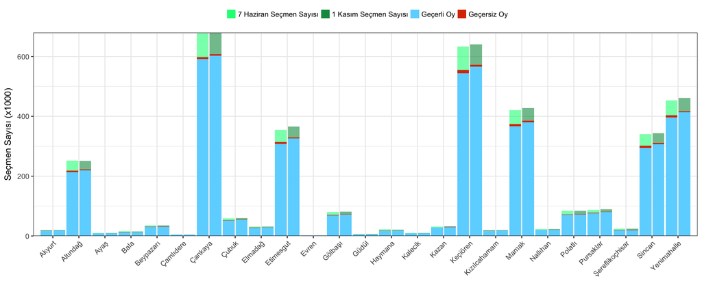

İlçelerin kayıtlı seçmen, geçerli ve geçersiz oy sayıları.

## Parti Oy Oranları

### AK Parti

AK Parti, 7 Haziran seçimlerinde Ankara ilçeleri arasında en yüksek oy oranını Çamlıdere (%72.35), en düşük oy oranını Çankaya (%18.91) ilçelerinde görmüştür. 1 Kasım seçimlerinde ise en yüksek oy oranını Çamlıdere (%80.63), en düşük oy oranını Çankaya (%22.42) ilçelerinde görmüştür. Parti bütün ilçelerde oy oranlarını yükseltmiştir. Puan bazında en büyük yükseliş Beypazarı ilçesinde (+%11.64) görülmektedir.

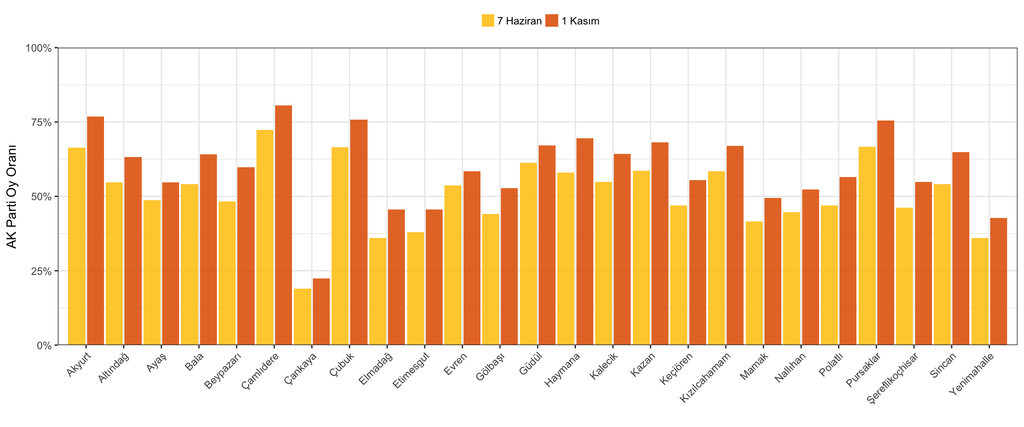

AK Parti’nin ilçelerde aldığı oy oranları.

### CHP

CHP, 7 Haziran seçimlerinde Ankara ilçeleri arasında en yüksek oy oranını Çankaya (%51.57), en düşük oy oranını Akyurt (%8.72) ilçelerinde görmüştür. 1 Kasım seçimlerinde ise en yüksek oy oranını Çankaya (%55.93), en düşük oy oranını Akyurt (%7.97) ilçelerinde görmüştür. Puan bazında en büyük yükseliş Çankaya ilçesinde (+%4.36) görülmektedir. Puan bazında en büyük düşüş ise Nallıhan ilçesinde (-%1.69) görülmektedir.

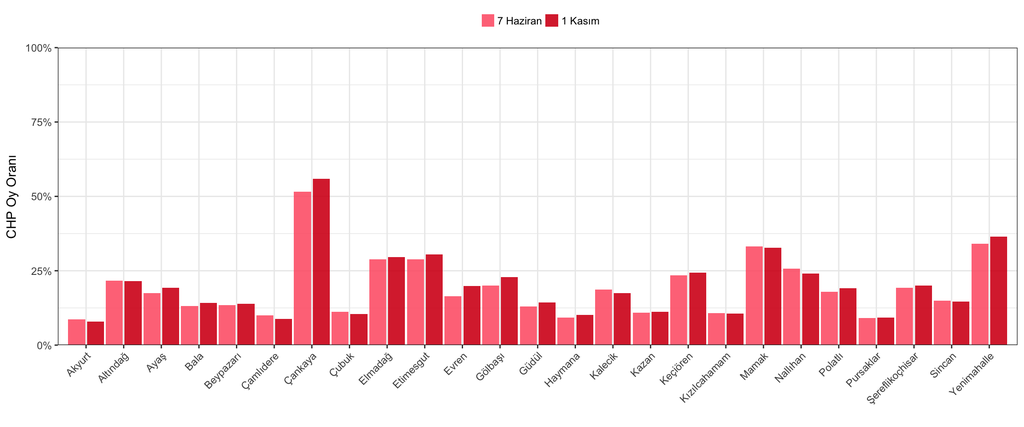

CHP’nin ilçelerde aldığı oy oranları.

### MHP

MHP, 7 Haziran seçimlerinde Ankara ilçeleri arasında en yüksek oy oranını Beypazarı (%28.8), en düşük oy oranını Haymana (%9.4) ilçelerinde görmüştür. 1 Kasım seçimlerinde ise en yüksek oy oranını Beypazarı (%23.02), en düşük oy oranını Haymana (%6.55) ilçelerinde görmüştür. Parti hiçbir ilçede oy oranını yükseltememiştir. Puan bazında en büyük düşüş Bala ilçesinde (-%6.5) görülmektedir.

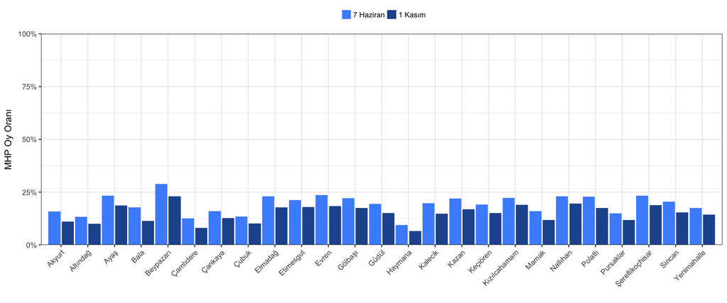

MHP’nin ilçelerde aldığı oy oranları.

### HDP

HDP, 7 Haziran seçimlerinde Ankara ilçeleri arasında en yüksek oy oranını Haymana (%18.52), en düşük oy oranını Çamlıdere (%0.32) ilçelerinde görmüştür. 1 Kasım seçimlerinde ise en yüksek oy oranını Haymana (%11.38), en düşük oy oranını Çamlıdere (%0.14) ilçelerinde görmüştür. Parti hiçbir ilçede oy oranını yükseltememiştir. Puan bazında en büyük düşüş Haymana ilçesinde (-%7.14) görülmektedir.

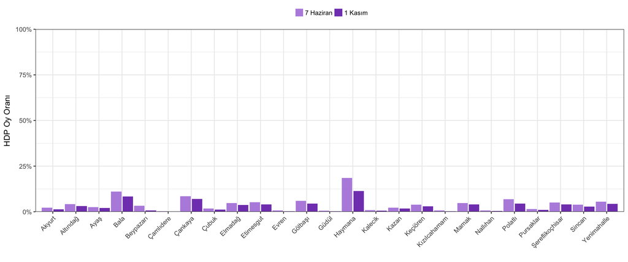

HDP’nin ilçelerde aldığı oy oranları.

# Bilinmesi Gerekenler

- Bu döküman otomatik olarak oluşturulmuştur.
- Dökümanın amacı R ile veri analizi, görselleştirme ve otomatik raporlama konusunda bir eğitim örneği oluşturmaktır.
- Bu dökümanı oluşturmakta kullanılan veriler 7 Haziran ve 1 Kasım’a ait sandık bazında seçim sonucu verilerinden oluşmaktadır. Veriler TÜİK vasıtasıyla YSK kesin seçim sonuçlarından elde edilmiştir.
- Veriler veya hesaplamalarda yanlışlıklar olabilir. Veriler ve analizlerle ilgili herhangi bir sorumluluk kabul edilmemektedir.
- İlgili veri setleri ve analizlere `secimler` R paketi vasıtasıyla ulaşılabilir. Paket hala geliştirme aşamasında olup sürekli güncellenmektedir. https://github.com/berkorbay/secimler adresinden pakete ulaşılabilir ve yükleme talimatları görülebilir.
- Paketin yazarına (Berk Orbay) http://berkorbay.me adresinden ulaşabilirsiniz.
[^1]: Örneğin, AK Parti 43 ilde daha yüksek, 37 ilde ise daha düşük oy oranı görmüştür.
[^2]: Örneğin, AK Parti 46 ilde daha yüksek, 34 ilde ise daha düşük oy oranı görmüştür.